# Unicef

- Show All Code
- Hide All Code
- View Source

Child Dependency Quatro Report - 2023

This Dashboard compares the Child Dependency Ratio with Gross National Income, Population and GDP per Capita.

Author

Shakthi Rishi R V - 22264249 - DCU

Published

27-04-2023

## 1 Executive Summary

All the data used in this report is from **UNICEF**.

Check out the Tableau version of this report - [Click Here](https://public.tableau.com/views/ChildDependencyDashboard/Dshboard2?:language=en-GB&publish=yes&:display_count=n&:origin=viz_share_link)

### 1.1 Key Highlights

- There is a **Correlation** between the Child Dependency Ratio and Population, Gross National Income & GDP per Capita.
- As the **population grows**, the **child dependency ratio reduces** which clearly indicates that there are more adults now than before to take care of children in a macro view.
- The **Child dependency ratio decreases** with **increase in Gross National Income, GDP per Capita and Population**. Now, it helps to understand that the individual Income of people also plays a crucial factor alongside population.
- The **more the income of people** across population growth, the **lesser the child dependency** is. This also means that the adult individuals are now **more financially stable** and capable of taking responsibility for more children than before, which reduces the child dependency significantly.
- Precisely, countries in *Africa* tend to have **Higher** Child Dependency comparitively, the possible reasons could be their:

  **- Low GDP per Capita**

  **- Slow Economic Growth of the Nation**

  **- Lesser Gross National Income**

## 2 The Child Dependency Story

### 2.1 Libraries & Data Preparation - Code

```r
library(ggplot2)
library(ggthemes)
library(magrittr)
library(dplyr)
library("tidyverse") # load dplyr, ggplot2, stringr, etc.
library("sf") # working with geographic simple features in R
library("rnaturalearth") # World map data from Natural Earth
library("countrycode") # get ISO code from country names
library("ggrepel") # "ggplot2" extension for overlapping text labels
library(readr)
unicef_metadata <- read_csv("~/Documents/DCU MiM Course Work/Data Analytics/mt5000importantdataandinstructionstableauassignmen/unicef_metadata.csv")
unicef_indicator_2 <- read_csv("~/Documents/DCU MiM Course Work/Data Analytics/mt5000importantdataandinstructionstableauassignmen/unicef_indicator_2.csv")
metadata_from_2009<- unicef_metadata %>%
  filter(year>2008)
world <- ne_countries(scale = "small", returnclass = "sf")
countries_obs_value<- world %>%
   select(geometry, name, iso_a3) %>%
     left_join(unicef_indicator_2, by = c("iso_a3" = "alpha_3_code")) %>%
     filter(time_period==2023) %>%
     filter(sex=="Total")
countries_obs_2023 <- unicef_indicator_2  %>%
      filter(time_period==2023) %>%
      filter(sex=="Total")
Countries_over80 <- countries_obs_2023 %>%
     filter(obs_value>80)
Countires_under20 <- countries_obs_2023 %>%
     filter(obs_value<20)
```

### 2.2 World Statistics

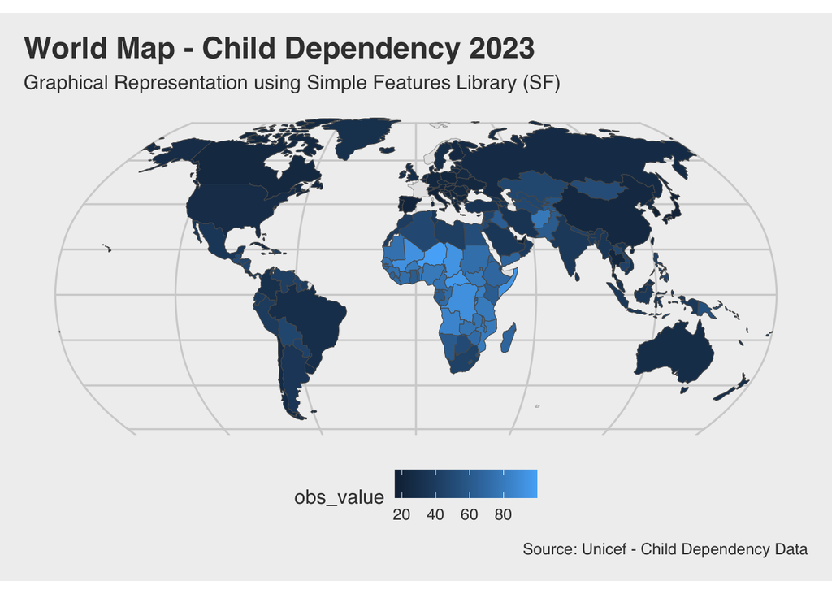

```r
world %>%
 filter(admin != "Antarctica") %>%
 st_transform(crs = "+proj=robin") %>%
 ggplot() +
 geom_sf(color = "darkgrey") +
 geom_sf(data = countries_obs_value, aes(fill = obs_value)) +
 theme_fivethirtyeight() +
 theme(plot.title = element_text(face = "bold"),
   axis.text.x = element_blank(), legend.position = "bottom") +
 labs(title = "World Map - Child Dependency 2023",
   subtitle = "Graphical Representation using Simple Features Library (SF)",
   x = NULL, y = NULL, caption = "Source: Unicef - Child Dependency Data")
```

- As per the above World Map, it is noted that most countries in *Africa* tend to have **High** Child Dependency and countries like *South Korea, Japan, Singapore, UAE, Taiwan etc.* have **Low** Child Dependency.

### 2.3 Countries with High Child Dependency

- Countries in *Africa* tend to have **Higher** Child dependency ratios above 80 Comparitively (from Below Bar Chart).

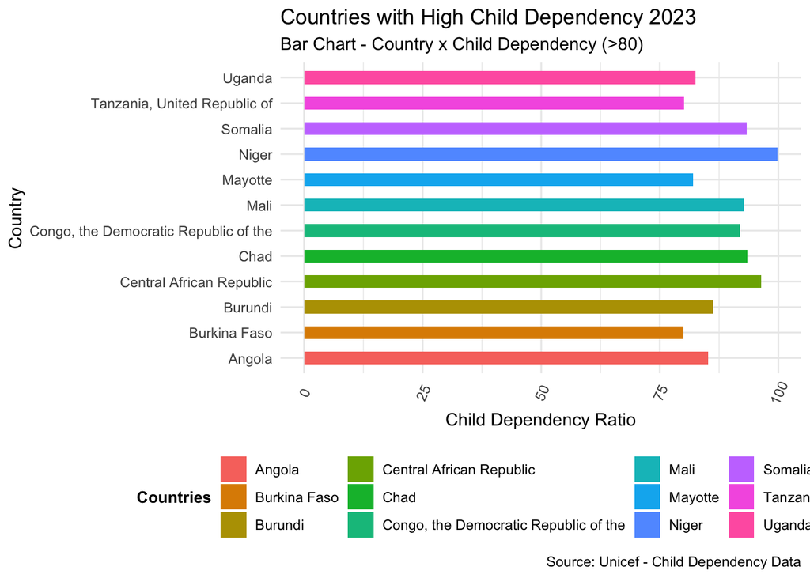

```r
ggplot(Countries_over80, aes(x = obs_value , y = country )) +
geom_col(aes(fill=country), width = 0.5) +
theme_minimal()+
theme(axis.text.x = element_text(angle=65, vjust=0.6), legend.position = "bottom") +
labs(title="Countries with High Child Dependency 2023",
 subtitle="Bar Chart - Country x Child Dependency (>80)",
 caption="Source: Unicef - Child Dependency Data",x="Child Dependency Ratio", y="Country") +
scale_fill_discrete(name = "Countries") +
theme(legend.title = element_text(colour="Black", size=10, face="bold"))
```

### 2.4 Countries with Low Child Dependency

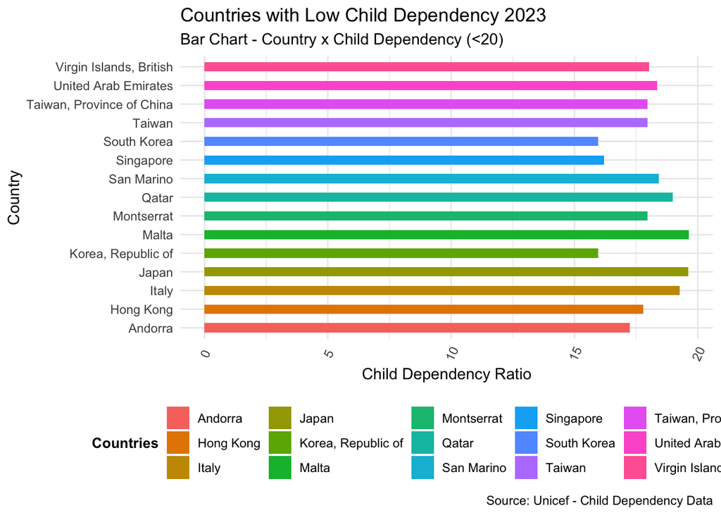

```r
ggplot(Countires_under20, aes(x = obs_value , y = country)) +
geom_col(aes(fill=country), width = 0.5)+
theme_minimal()+
theme(axis.text.x = element_text(angle=65, vjust=0.6),legend.position = "bottom") +
labs(title="Countries with Low Child Dependency 2023",
 subtitle="Bar Chart - Country x Child Dependency (<20)",
 caption="Source: Unicef - Child Dependency Data",x="Child Dependency Ratio", y="Country")+
scale_fill_discrete(name = "Countries")+
theme(legend.title = element_text(colour="Black", size=10, face="bold"))
```

### 2.5 World Child Dependency Ratio Trend

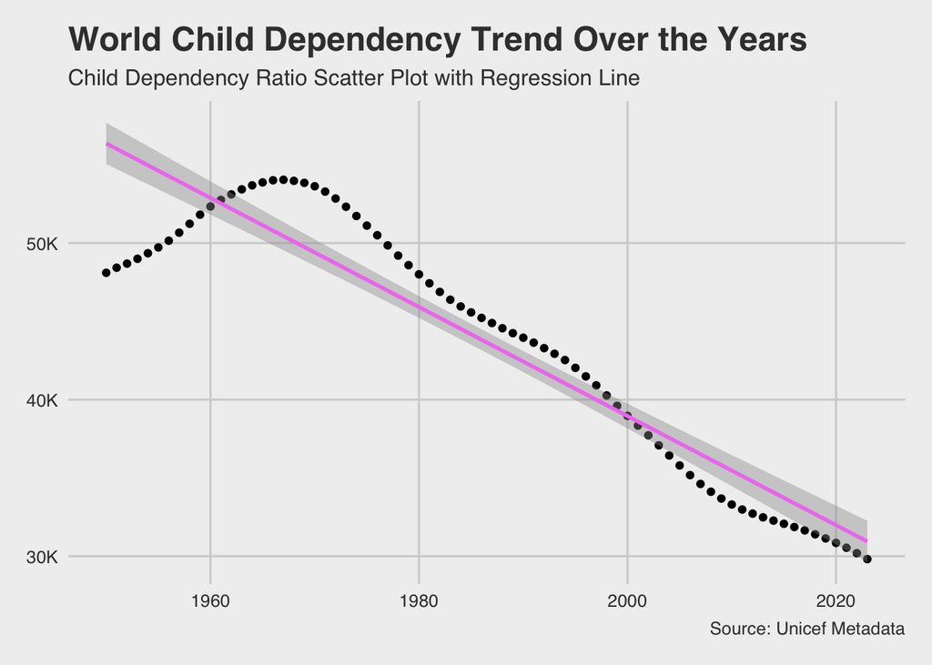

```r
unicef_indicator_2 %>%
 group_by(time_period)%>%
   summarise(s_obs=sum(obs_value)) %>%
     ggplot(aes(time_period,s_obs), color="seagreen4")+
     geom_point()+
     geom_smooth(method = 'lm',color = "violet")+
     scale_y_continuous(labels = scales::label_number_si())+
      labs(title="World Child Dependency Trend Over the Years",
      subtitle="Child Dependency Ratio Scatter Plot with Regression Line",
      caption="Source: Unicef Metadata",x="Year", y="Child Dependency Ratio")+
    scale_color_fivethirtyeight()+
    theme_fivethirtyeight()
```

### 2.6 Gross National Income Trend

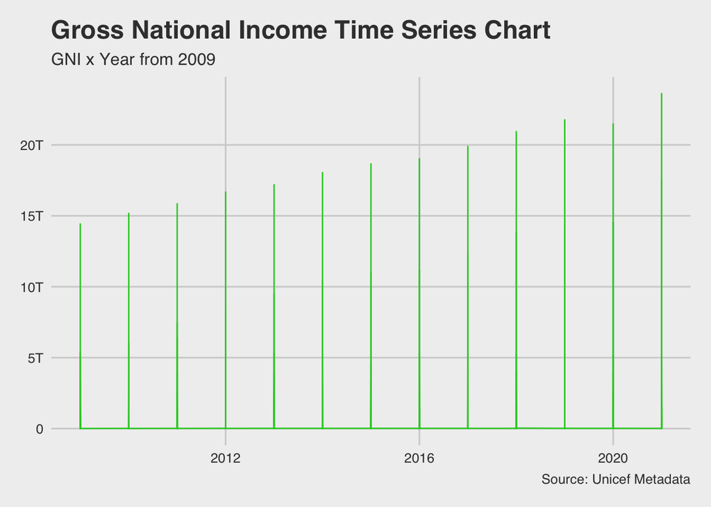

```r
ggplot(metadata_from_2009, aes(x=year)) +
geom_line(aes(y=`GNI (current US$)`),color="limegreen") +
 labs(title="Gross National Income Time Series Chart",
 subtitle="GNI x Year from 2009", caption="Source: Unicef Metadata",
 y="Gross National Income", x="Year")+
scale_y_continuous(labels = scales::label_number_si()) +
scale_color_fivethirtyeight()+
theme_fivethirtyeight()
```

**Insights:*

- GNI steadily **increases** over the years.
- Child Dependency reduces with Increase in Gross National Income.

### 2.7 Population Growth

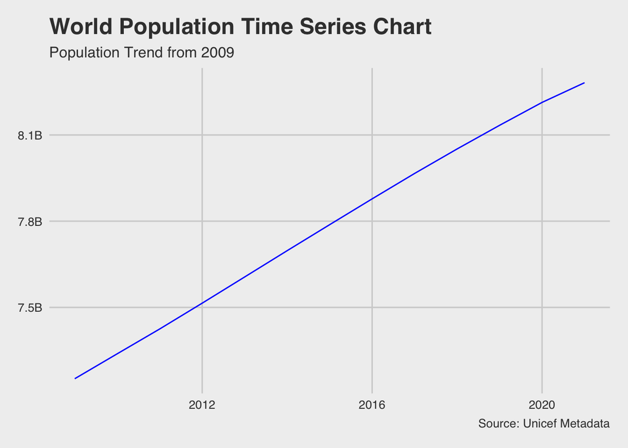

```r
metadata_from_2009 %>%
 group_by(year)%>%
   summarise(s_pop=sum(`Population, total`)) %>%
     ggplot(aes(year,s_pop), color="seagreen4")+
     geom_line(color="blue")+
     scale_y_continuous(labels = scales::label_number_si())+
      labs(title="World Population Time Series Chart",
      subtitle="Population Trend from 2009",
      caption="Source: Unicef Metadata",x="Year", y="Population")+
    scale_color_fivethirtyeight()+
    theme_fivethirtyeight()
```

**Insights:**

- Population **increases** rapidly over the years with **Decreasing Child Dependency Ratio**.

### 2.8 Gross National Income with Population

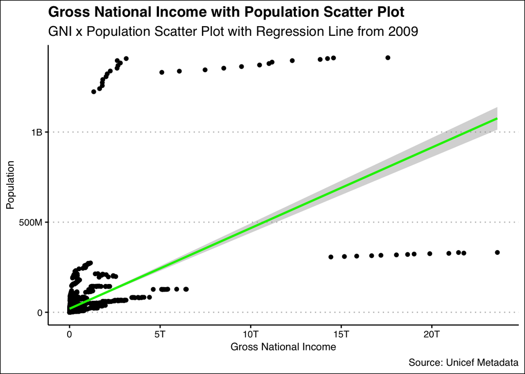

```r
 metadata_from_2009 %>%
 group_by(year)%>%
 ggplot(aes(y=`Population, total`, x=`GNI (current US$)`))+
    geom_point()+
  theme_clean()+
   geom_smooth(method = 'lm', ,color = "green2")+

  labs(title="Gross National Income with Population Scatter Plot",
      subtitle="GNI x Population Scatter Plot with Regression Line from 2009",
      caption="Source: Unicef Metadata",x="Gross National Income", y="Population")+
  scale_y_continuous(labels = scales::label_number_si()) +
  scale_x_continuous(labels = scales::label_number_si()) +
    scale_color_fivethirtyeight()
```

**Insights:**

- Population **Increases** rapidly over the years with **Increasing Gross National Income**.
- The Increasing trend in both Population and Gross National Income over the years highlights that the economic situation is constantly improving which is **inversly proportional** to the Child Dependency ratio, which is in decreasing trend.

### 2.9 GDP Per Capita

- Sum of gross value added by all resident producers in the economy plus any product taxes (less subsidies) not included in the valuation of output, divided by mid-year population.

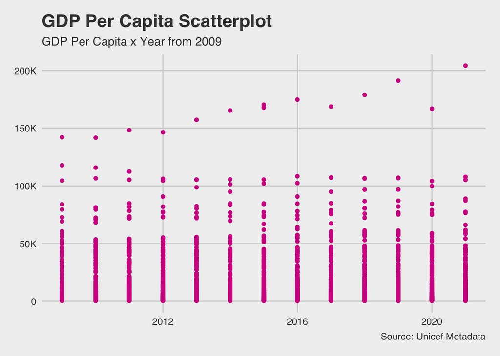

```r
metadata_from_2009 %>%
 group_by(year)%>%
ggplot(aes(x=year)) +
geom_point(aes(y=`GDP per capita (constant 2015 US$)`),color="violetred") +
labs(title="GDP Per Capita Scatterplot",
     subtitle="GDP Per Capita x Year from 2009",
     caption="Source: Unicef Metadata",
     y="GDP Per Capita", x="Year") +
scale_y_continuous(labels = scales::label_number_si()) +
    scale_color_fivethirtyeight()+
    theme_fivethirtyeight()
```

**Insights:**

- As **GDP Per Capita Increases** over the years with **Decreasing Child Dependency Ratio**.